# Data cleaning dan visual data exploratory

## Pemeriksaan kolom region

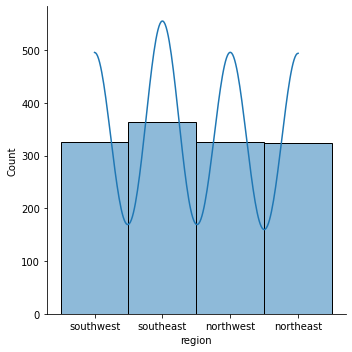

```python
sns.displot(data = df, x = df["region"], kde=True)
```

Terdapat 4 region yang masing-masing memiliki jumlah yang mirip, yaitu sekitar 300

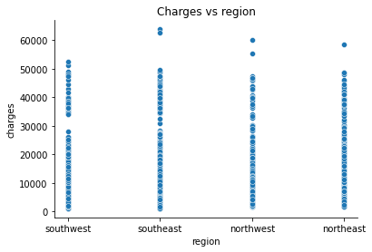

```python
sns.scatterplot(x= df['region'] , y= df['charges'], data=df).set_title('Charges vs region')
sns.despine()
```

Tidak terlihat adanya pola yang dipengaruhi oleh region terhadap biaya premi yang diberikan

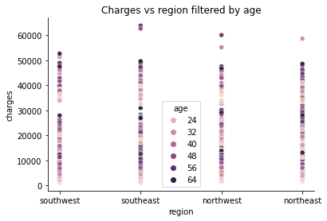

```python
sns.scatterplot(x= df['region'] , y= df['charges'], hue= "age", data=df).set_title('Charges vs region filtered by age')
sns.despine()
```

Tidak terlihat adanya pengaruh dari umur pemegang asuransi terhadap perbandingan region dengan harga premi asuransi

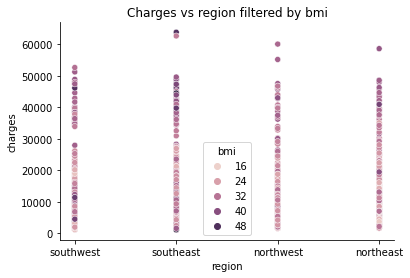

```python
sns.scatterplot(x= df['region'] , y= df['charges'], hue= "bmi", data=df).set_title('Charges vs region filtered by bmi')
sns.despine()
```

Tidak terlihat adanya pengaruh dari BMI terhadap perbandingan region dengan harga premi yang harus dibayarkan

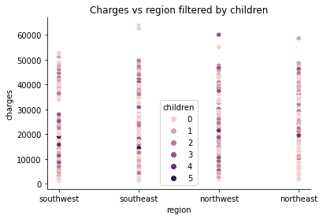

```python
sns.scatterplot(x= df['region'] , y= df['charges'], hue= "children", data=df).set_title('Charges vs region filtered by children')
sns.despine()
```

Tidak terlihat adanya pengaruh dari jumlah anak terhadap perbandingan dari region dengan biaya premi asuransi

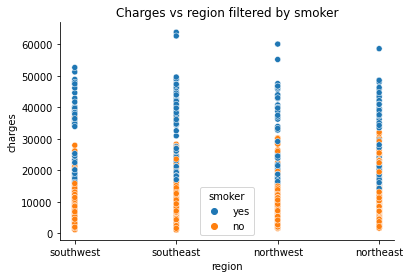

```python
sns.scatterplot(x= df['region'] , y= df['charges'], hue= "smoker", data=df).set_title('Charges vs region filtered by smoker')
sns.despine()
```

Terlihat bahwa adanya pengaruh dari sifat perokok terhadap perbandingan region dengan harga biaya premi asuransi, dimana perokok cenderung memiliki biaya premi asuransi yang mahal

# Grafik korelasi antara independent variable dengan dependent variable

1. Umur
2. BMI
3. Jumlah anak
4. Sifat perokok
5. Region
6. Jenis kelamin

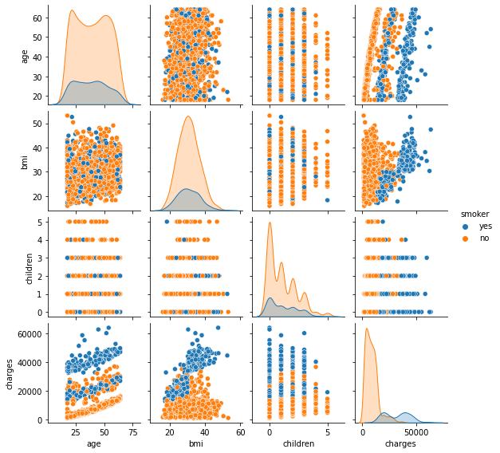

```python
sns.pairplot(df.iloc[:,[0,1,2,3,4,5,6]], hue='smoker', diag_kind='kde',height=2)
```

```python
df_dummies1 = df.copy()
df_dummies1['sex'] = df_dummies1['sex'].apply({'female':0,'male':1}.get)
df_dummies1['smoker'] = df_dummies1['smoker'].apply({'yes':1, 'no':0}.get)
df_dummies1['region'] = df_dummies1['region'].apply({'northwest':1, 'southeast':2, 'southwest':3, 'northeast':4}.get)
df_dummies1.head()
```

|  | age | sex | bmi | children | smoker | region | charges |
| --- | --- | --- | --- | --- | --- | --- | --- |
| 0 | 19 | 0 | 27.900 | 0 | 1 | 3 | 16884.92400 |
| 1 | 18 | 1 | 33.770 | 1 | 0 | 2 | 1725.55230 |
| 2 | 28 | 1 | 33.000 | 3 | 0 | 2 | 4449.46200 |
| 3 | 33 | 1 | 22.705 | 0 | 0 | 1 | 21984.47061 |
| 4 | 32 | 1 | 28.880 | 0 | 0 | 1 | 3866.85520 |

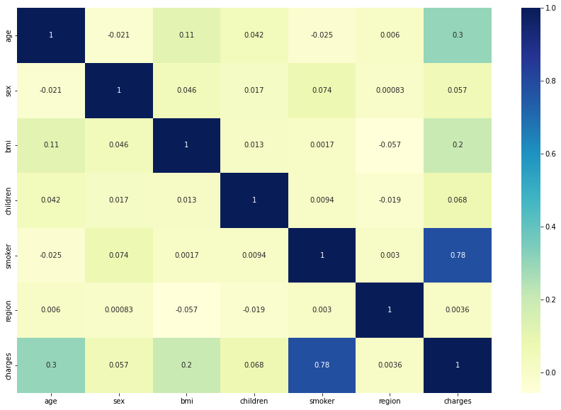

```python
import matplotlib.pyplot as plt

corr_dummies1 = df_dummies1.corr()
plt.figure(figsize=(15, 10))
sns.heatmap(corr_dummies1, annot=True, cmap = 'YlGnBu')
```

```python
corr_dummies1["charges"].sort_values(ascending=False)
```

```
charges     1.000000
smoker      0.784572
age         0.299008
bmi         0.197666
children    0.067998
sex         0.057292
region      0.003642
Name: charges, dtype: float64
```

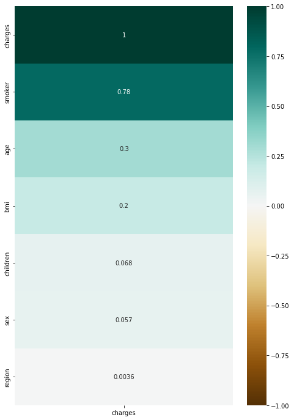

```python
corr = df_dummies1.corr()[['charges']].sort_values(by='charges', ascending=False)
plt.figure(figsize=(8, 12))
sns.heatmap(corr, vmin=-1, vmax=1, annot=True, cmap = 'BrBG')
```

Dari tampilan data correlation di atas, kita dapat melihat variabel apa saja yang paling berpengaruh terhadap harga premi asuransi. Dalam urutannya yang paling berpengaruh adalah

1. Smoker
2. Age
3. BMI
4. Children
5. Sex
6. Region

Untuk dapat melihat lebih detail lagi pilihan apa saja yang sangat mempengaruhi harga dapat dilakukan correlation seperti di bawah ini

```python
dummies = pd.get_dummies(df[['sex','smoker','region']])
df_dummies2 = df[['charges','age','bmi','children']].join(dummies)
df_dummies2.head()
```

|  | charges | age | bmi | children | sex_female | sex_male | smoker_no | smoker_yes | region_northeast | region_northwest | region_southeast | region_southwest |
| --- | --- | --- | --- | --- | --- | --- | --- | --- | --- | --- | --- | --- |
| 0 | 16884.92400 | 19 | 27.900 | 0 | 1 | 0 | 0 | 1 | 0 | 0 | 0 | 1 |
| 1 | 1725.55230 | 18 | 33.770 | 1 | 0 | 1 | 1 | 0 | 0 | 0 | 1 | 0 |
| 2 | 4449.46200 | 28 | 33.000 | 3 | 0 | 1 | 1 | 0 | 0 | 0 | 1 | 0 |
| 3 | 21984.47061 | 33 | 22.705 | 0 | 0 | 1 | 1 | 0 | 0 | 1 | 0 | 0 |
| 4 | 3866.85520 | 32 | 28.880 | 0 | 0 | 1 | 1 | 0 | 0 | 1 | 0 | 0 |

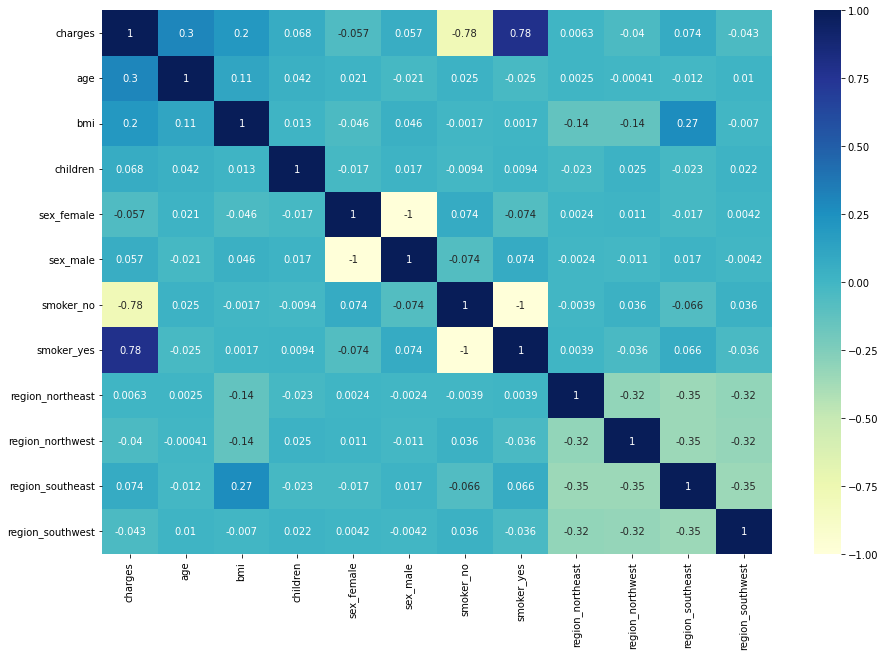

```python
plt.figure(figsize = (15,10))
corr_matrix = df_dummies2.corr()
sns.heatmap(corr_matrix, annot=True,cmap='YlGnBu')
```

```python
corr_matrix["charges"].sort_values(ascending=False)
```

```
charges             1.000000
smoker_yes          0.784572
age                 0.299008
bmi                 0.197666
region_southeast    0.073982
children            0.067998
sex_male            0.057292
region_northeast    0.006349
region_northwest   -0.039905
region_southwest   -0.043210
sex_female         -0.057292
smoker_no          -0.784572
Name: charges, dtype: float64
```

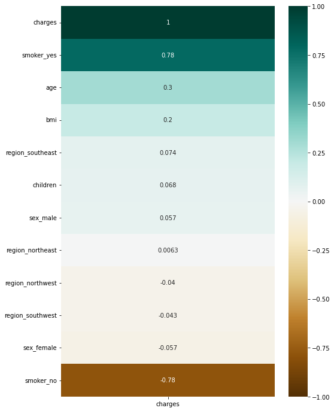

```python
corr = df_dummies2.corr()[['charges']].sort_values(by='charges', ascending=False)
plt.figure(figsize=(8, 12))
sns.heatmap(corr, vmin=-1, vmax=1, annot=True, cmap = 'BrBG')
```

Dari hasil perhitungan korelasi antara independent variable dengan dependent variable, kita dapat melihat bahwa hubungan yang paling erat dalam penentuan harga pada premi asuransi berkaitan erat dengan beberapa faktor, yang diurutkan menjadi

1. Smoker (yes)
2. Age
3. BMI
4. region (southeast)
5. Children
6. Sex (male)
7. Region (northeast, northwest, southwest)
8. Sex (female)
9. Smoker (no)

# Pembuatan Training Set dan Test Set

dengan proporsi training set dan test set sebesar 4:1

```python
df_linearReg = df.copy()
```

```python
df_linearReg
```

|  | age | sex | bmi | children | smoker | region | charges |
| --- | --- | --- | --- | --- | --- | --- | --- |
| 0 | 19 | female | 27.900 | 0 | yes | southwest | 16884.92400 |
| 1 | 18 | male | 33.770 | 1 | no | southeast | 1725.55230 |
| 2 | 28 | male | 33.000 | 3 | no | southeast | 4449.46200 |
| 3 | 33 | male | 22.705 | 0 | no | northwest | 21984.47061 |
| 4 | 32 | male | 28.880 | 0 | no | northwest | 3866.85520 |
| ... | ... | ... | ... | ... | ... | ... | ... |
| 1333 | 50 | male | 30.970 | 3 | no | northwest | 10600.54830 |
| 1334 | 18 | female | 31.920 | 0 | no | northeast | 2205.98080 |
| 1335 | 18 | female | 36.850 | 0 | no | southeast | 1629.83350 |
| 1336 | 21 | female | 25.800 | 0 | no | southwest | 2007.94500 |
| 1337 | 61 | female | 29.070 | 0 | yes | northwest | 29141.36030 |

1338 rows × 7 columns

```python
x = df_linearReg.iloc[:,:6]
x
```

|  | age | sex | bmi | children | smoker | region |
| --- | --- | --- | --- | --- | --- | --- |
| 0 | 19 | female | 27.900 | 0 | yes | southwest |
| 1 | 18 | male | 33.770 | 1 | no | southeast |
| 2 | 28 | male | 33.000 | 3 | no | southeast |
| 3 | 33 | male | 22.705 | 0 | no | northwest |
| 4 | 32 | male | 28.880 | 0 | no | northwest |
| ... | ... | ... | ... | ... | ... | ... |
| 1333 | 50 | male | 30.970 | 3 | no | northwest |
| 1334 | 18 | female | 31.920 | 0 | no | northeast |
| 1335 | 18 | female | 36.850 | 0 | no | southeast |
| 1336 | 21 | female | 25.800 | 0 | no | southwest |
| 1337 | 61 | female | 29.070 | 0 | yes | northwest |

1338 rows × 6 columns

```python
from sklearn.preprocessing import LabelEncoder, OneHotEncoder
le = LabelEncoder()
x.iloc[:, 1] = le.fit_transform(x.iloc[:, 1])
x.iloc[:, 4] = le.fit_transform(x.iloc[:, 4])
x.iloc[:, 5] = le.fit_transform(x.iloc[:, 5])
x
```

|  | age | sex | bmi | children | smoker | region |
| --- | --- | --- | --- | --- | --- | --- |
| 0 | 19 | 0 | 27.900 | 0 | 1 | 3 |
| 1 | 18 | 1 | 33.770 | 1 | 0 | 2 |
| 2 | 28 | 1 | 33.000 | 3 | 0 | 2 |
| 3 | 33 | 1 | 22.705 | 0 | 0 | 1 |
| 4 | 32 | 1 | 28.880 | 0 | 0 | 1 |
| ... | ... | ... | ... | ... | ... | ... |
| 1333 | 50 | 1 | 30.970 | 3 | 0 | 1 |
| 1334 | 18 | 0 | 31.920 | 0 | 0 | 0 |
| 1335 | 18 | 0 | 36.850 | 0 | 0 | 2 |
| 1336 | 21 | 0 | 25.800 | 0 | 0 | 3 |
| 1337 | 61 | 0 | 29.070 | 0 | 1 | 1 |

1338 rows × 6 columns

```python
y = df_linearReg.iloc[:,-1]
y
```

```
0       16884.92400
1        1725.55230
2        4449.46200
3       21984.47061
4        3866.85520
           ...
1333    10600.54830
1334     2205.98080
1335     1629.83350
1336     2007.94500
1337    29141.36030
Name: charges, Length: 1338, dtype: float64
```

```python
from sklearn.model_selection import train_test_split
x_train, x_test, y_train, y_test = train_test_split(x, y, test_size = 0.2, random_state = 0)
```

```python
x_train
```

|  | age | sex | bmi | children | smoker | region |
| --- | --- | --- | --- | --- | --- | --- |
| 621 | 37 | 1 | 34.100 | 4 | 1 | 3 |
| 194 | 18 | 1 | 34.430 | 0 | 0 | 2 |
| 240 | 23 | 0 | 36.670 | 2 | 1 | 0 |
| 1168 | 32 | 1 | 35.200 | 2 | 0 | 3 |
| 1192 | 58 | 0 | 32.395 | 1 | 0 | 0 |
| ... | ... | ... | ... | ... | ... | ... |
| 763 | 27 | 1 | 26.030 | 0 | 0 | 0 |
| 835 | 42 | 1 | 35.970 | 2 | 0 | 2 |
| 1216 | 40 | 1 | 25.080 | 0 | 0 | 2 |
| 559 | 19 | 1 | 35.530 | 0 | 0 | 1 |
| 684 | 33 | 0 | 18.500 | 1 | 0 | 3 |

1070 rows × 6 columns

```python
y_train
```

```
621     40182.24600
194      1137.46970
240     38511.62830
1168     4670.64000
1192    13019.16105
           ...
763      3070.80870
835      7160.33030
1216     5415.66120
559      1646.42970
684      4766.02200
Name: charges, Length: 1070, dtype: float64
```

```python
from sklearn.preprocessing import StandardScaler
sc = StandardScaler()
x_train = sc.fit_transform(x_train)
x_test = sc.transform(x_test)
```

# Permodelan Linear Regression

```python
from sklearn.linear_model import LinearRegression
model = LinearRegression()
```

## Prediksi menggunakan test set

```python
model.fit(x_train, y_train)

y_train_pred = model.predict(x_train)
y_test_pred = model.predict(x_test)
```

## Tampilkan hasil prediksi tersebut dengan nilai sebenarnya dari test set

```python
df_perbandingan = pd.DataFrame({'Actual': y_train, 'Predicted': y_train_pred})
df_perbandingan[:20]
```

|  | Actual | Predicted |
| --- | --- | --- |
| 621 | 40182.24600 | 33394.916005 |
| 194 | 1137.46970 | 3619.461984 |
| 240 | 38511.62830 | 30680.269354 |
| 1168 | 4670.64000 | 8025.342678 |
| 1192 | 13019.16105 | 14145.579510 |
| 1279 | 4189.11310 | 4089.329205 |
| 49 | 38709.17600 | 32458.194047 |
| 597 | 5594.84550 | 8334.005106 |
| 539 | 27346.04207 | 11493.958098 |
| 425 | 9788.86590 | 9373.079985 |
| 692 | 2362.22905 | 4190.245259 |
| 466 | 13224.69300 | 12582.380986 |
| 575 | 12222.89830 | 11703.334859 |
| 923 | 4320.41085 | 8421.163535 |
| 446 | 12730.99960 | 13283.679666 |
| 471 | 2203.47185 | 2802.146279 |
| 44 | 6079.67150 | 10571.175029 |
| 1092 | 3591.48000 | 5365.025528 |
| 969 | 8596.82780 | 11153.811783 |
| 1188 | 21771.34230 | 31577.601185 |

```python
df_perbandingan = pd.DataFrame({'Actual': y_test, 'Predicted': y_test_pred})
df_perbandingan[:20]
```

|  | Actual | Predicted |
| --- | --- | --- |
| 578 | 9724.53000 | 11019.959731 |
| 610 | 8547.69130 | 9788.901476 |
| 569 | 45702.02235 | 37992.196113 |
| 1034 | 12950.07120 | 16114.944555 |
| 198 | 9644.25250 | 6937.940490 |
| 981 | 4500.33925 | 3975.827269 |
| 31 | 2198.18985 | 1556.883178 |
| 1256 | 11436.73815 | 14276.368055 |
| 1219 | 7537.16390 | 8953.112939 |
| 1320 | 5425.02335 | 7433.147933 |
| 613 | 6753.03800 | 4550.957209 |
| 1107 | 10493.94580 | 10248.121617 |
| 1263 | 7337.74800 | 8660.626289 |
| 406 | 4185.09790 | 4133.865129 |
| 795 | 18310.74200 | 27821.508255 |
| 970 | 10702.64240 | 11040.542047 |
| 824 | 12523.60480 | 11253.647805 |
| 141 | 3490.54910 | 6030.980007 |
| 1173 | 6457.84340 | 8175.066519 |
| 1042 | 33475.81715 | 27047.435133 |

# Evaluasi Linear Regression

Oleh karena terdapat 6 indepedenent variabel yang mempengaruhi prediksi harga, maka persamaan linearnya adalah sebagai berikut:

**y = B0 + B1 x1 + B2 x2 + B3 x3 + B4 x4 + B5 x5 + B6 x6 + e**

sehingga untuk kasus kita persamaan regresi tersebut adalah

**y = intercept + (age *coef age) + (sex* coef sex) + (bmi *coef bmi) + (children* coef children) + (smoker *coef smoker) + (region* coef region) + e**

Kemudian berikut adalah coefficient dari masing-masing independent variabel

```python
pd.DataFrame(model.coef_, x.columns, columns = ['Coefficient'])
```

|  | Coefficient |
| --- | --- |
| age | 3574.247632 |
| sex | -11.691832 |
| bmi | 2025.575745 |
| children | 536.388581 |
| smoker | 9511.318921 |
| region | -317.014319 |

```python
print("Model intercept: ", model.intercept_)
```

```
Model intercept:  13201.182056009346
```

Melalui nilai di atas kita dapat melihat bagaimana sebuah coefficient mempengaruhi prediksi sebuah nilai. Pada analisa kita di atas menunjukkan bahwa yang paling mempengaruhi prediksi harga premi asuransi adalah secara berurutan : sifat perokok, umur, bmi, jumlah anak, wilayah, dan diikuti dengan yang paling terakhir adalah jenis kelamin.

```python
from sklearn import metrics

print('The R2 (Variance) is: ', metrics.r2_score(y_test, y_test_pred))
print('Mean Absolute Error (MAE):', metrics.mean_absolute_error(y_test, y_test_pred))
print('Mean Squared Error (MSE):', metrics.mean_squared_error(y_test, y_test_pred))
print('Root Mean Squared Error (RMSE) is: ', metrics.mean_squared_error(y_test, y_test_pred, squared=False))
```

```
The R2 (Variance) is:  0.780228039022998
Mean Absolute Error (MAE): 4017.6519831434794
Mean Squared Error (MSE): 34972303.869729996
Root Mean Squared Error (RMSE) is:  5913.738569613134
```

**Nilai R2** atau variance dalam linear regression adalah sebuah perhitungan antara nilai total dari selisih nilai prediksi dengan mean dan dikuadratkan yang dibagi dengan selisih nilai sebenarnya dengan mean dan dikuadratkan. Kemudian nilai tersebut digunakan untuk selisih dengan 1. Sehingga semakin mendekati nilai 1, maka model tersebut semakin baik dalam mewakili data yang diprediksi. Dalam hal ini model linear regression di atas memiliki nilai 0.78, yang cukup mendekati 1, sehingga dapat disimpulkan bahwa model linear regression yang dibuat cukup baik.

**Mean Absolute Error** (MAE) merupakan rata-rata dari perbedaan antara nilai yang diprediksi dengan nilai sebenarnya. MAE dihitung dari selisih antara nilai sebenarnya dengan nilai hasil prediksi, kemudian semua dijumlahkan, lalu dibagi dengan total banyaknya data, sehingga kita mendapatkan rata-rata dari error antara nilai sebenarnya dengan hasil prediksi. Semakin rendah nilai MAE maka akan semakin tinggi akurasi prediksi dari model regression. Dalam hal ini nilai MAE menyentuh angka 4017.65 yang berarti nilainya error yang dihasilkan ketika prediksi rata-ratanya adalah 4017.65. Menurut saya nilai ini cukup bagus karena range harga dalam data training adalah sekitar 1000 hingga 64000, sehingga nilai error sebesar 4000 cukup dapat ditolerir.

**Root Mean Squared Error** (RSME) merupakan sebuah perhitungan untuk menghitung perubahan antara nilai asli dengan nilai yang diprediksi oleh sebuah model. Perhitungannya adalah nilai dari total dari selisih nilai prediksi dengan nilai sebenarnya, kemudian dikuadratkan dan dibagi dengan banyaknya data, lalu hasil semuanya diakarkan. Bisa dibilang bahwa RMSE adalah MSE yang dioperasikan akar pangkat 2. Nilai yang didapatkan oleh RSME merupakan estimasi dari selisih yang mungkin terjadi antara nilai prediksi dengan nilai asli. Dalam hal ini memperhatikan range dari nilai yang diprediksi dan tingkat toleransi yang kita miliki. Dalam kasus ini, nilai harga yang diberikan adalah berkisar dari 1000 hingga 64000, sehingga nilai RMSE sebesar 5900 menurut saya cukup dapat ditolerir.

# Predicted Value vs Measure/Actual Value

Berikut adalah visualisasi hasil dari hasil training dengan hasil test

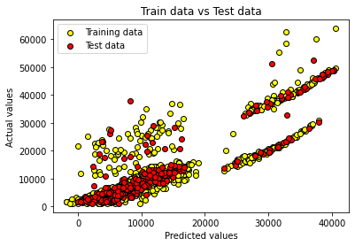

```python
plt.scatter(model.predict(x_train), y_train, edgecolor="k", c = "yellow",  label = "Training data")
plt.scatter(model.predict(x_test), y_test, edgecolor="k", c = "red",  label = "Test data")
plt.title("Train data vs Test data")
plt.xlabel("Predicted values")
plt.ylabel("Actual values")
plt.legend(loc = "upper left")
plt.show()
```

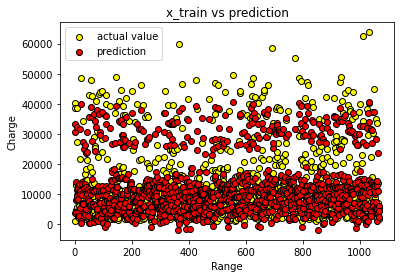

```python
def plotGraph(y_test,y_pred,regressorName):
    if max(y_test) >= max(y_pred):
        my_range = int(max(y_test))
    else:
        my_range = int(max(y_pred))
    plt.scatter(range(len(y_test)), y_test, edgecolor="k", color='yellow', label= "actual value")
    plt.scatter(range(len(y_pred)), y_pred, edgecolor="k", color='red', label = "prediction")
    plt.title(regressorName)
    plt.xlabel("Range")
    plt.ylabel("Charge")
    plt.legend(loc = "upper left")
    plt.show()
    return

plotGraph(y_train, y_train_pred, "x_train vs prediction")
```

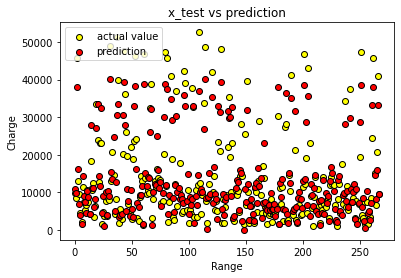

```python
plotGraph(y_test, y_test_pred, "x_test vs prediction")
```